# Predicting Location in Drug Overdose Related Deaths

Holly Stephens & Jonathan Cabrera

# Introduction

We chose to use the Accidental Drug Related Deaths dataset for our final project, and because of how prolific news stories of the opioid crisis have become in recent years, we felt a natural propensity towards drug overdose deaths related to opioids. After some exploration, we decided we wanted to predict the likelihood of an overdose death occurring in a major city.

# Data

The Accidental Drug Related Deaths dataset is from a government site containing information about the accidental deaths associated with drug overdose in Connecticut from 2012 to 2018. It was collected by the Office of the Chief Medical Examiner and includes information such as the toxicity report, death certificate, and a scene investigation of each overdose death. It should be noted here that Connecticut is also the headquarters of Purdue Pharma L.P., a company considered by many to be one of the actuators behind the opioid crisis.

# Initial Data Exploration

A first look at our dataset:

```r
# how large is our data?
ncol(dat)
```

```
## [1] 41
```

```r
nrow(dat)
```

```
## [1] 5105
```

```r
# what types of attributes exist in our dataframe?
unique(sapply(dat,class))
```

```
## [1] "factor"  "integer"
```

Exploring the demographic distribution:

```r
mean(na.omit(dat$Age))
```

```
## [1] 41.96492
```

```r
summary(dat$Sex)
```

```
##          Female    Male Unknown
##       6    1325    3773       1
```

```r
summary(dat$Race)
```

```
##                                  Asian Indian           Asian, Other
##                     13                     14                     18
##                  Black                Chinese               Hawaiian
##                    433                      2                      1
##        Hispanic, Black        Hispanic, White Native American, Other
##                     24                    561                      1
##                  Other                Unknown                  White
##                     11                     23                   4004
```

```r
summary(dat$DeathCity)
```

```
##         HARTFORD        NEW HAVEN        WATERBURY       BRIDGEPORT
##              563              374              368              341
##      NEW BRITAIN          MERIDEN          BRISTOL          NORWICH
##              227              145              144              144
##       NEW LONDON          DANBURY       TORRINGTON       MANCHESTER
##              137              131              114              102
##       MIDDLETOWN          ENFIELD         STAMFORD    EAST HARTFORD
##              100               81               76               71
##          MILFORD          NORWALK       WEST HAVEN            DERBY
##               70               69               69               65
##        STRATFORD      SOUTHINGTON      WILLIMANTIC           VERNON
##               55               53               51               48
##           HAMDEN      NEW MILFORD           GROTON        NAUGATUCK
##               46               44               42               42
##      WALLINGFORD         BRANFORD    WEST HARTFORD     WETHERSFIELD
##               36               35               31               30
##           PUTNAM          SHELTON       EAST HAVEN        NEWINGTON
##               28               28               27               26
##          WINDSOR          ANSONIA       PLAINVILLE        GREENWICH
##               24               23               23               22
##       FARMINGTON        WATERTOWN      GLASTONBURY    WINDSOR LOCKS
##               21               21               20               20
##          CLINTON           BERLIN       PLAINFIELD       TERRYVILLE
##               19               18               18               18
##     EAST WINDSOR      MARLBOROUGH      NORTH HAVEN           BETHEL
##               17               16               16               15
##     EAST HAMPTON          SEYMOUR      JEWETT CITY           SHARON
##               15               15               14               14
## STAFFORD SPRINGS         TRUMBULL        FAIRFIELD         PORTLAND
##               14               14               13               13
##          TOLLAND          WINSTED           MOOSUP       ROCKY HILL
##               12               12               11               11
##       UNCASVILLE        WESTBROOK       BLOOMFIELD           CANTON
##               11               11               10               10
##       COLCHESTER          LEDYARD     NORTH CANAAN     OLD SAYBROOK
##               10               10               10               10
##        WATERFORD         COVENTRY         CROMWELL          LEBANON
##               10                9                9                9
##          MADISON        MANSFIELD          NEWTOWN       BURLINGTON
##                9                9                9                8
##         CHESHIRE         COLUMBIA       DEEP RIVER        ELLINGTON
##                8                8                8                8
##            ESSEX        KILLINGLY       MIDDLEBURY          NIANTIC
##                8                8                8                8
##         SUFFIELD          WINDHAM        DANIELSON           HEBRON
##                8                8                7                7
##           MONROE         SIMSBURY       WINCHESTER          ASHFORD
##                7                7                7                6
##         DAYVILLE         GUILFORD   NORTH BRANFORD          (Other)
##                6                6                6              330
```

```r
summary(dat$MannerofDeath)
```

```
##          accident Accident ACCIDENT  Natural  Pending
##       10       13     5066        1        1       14
```

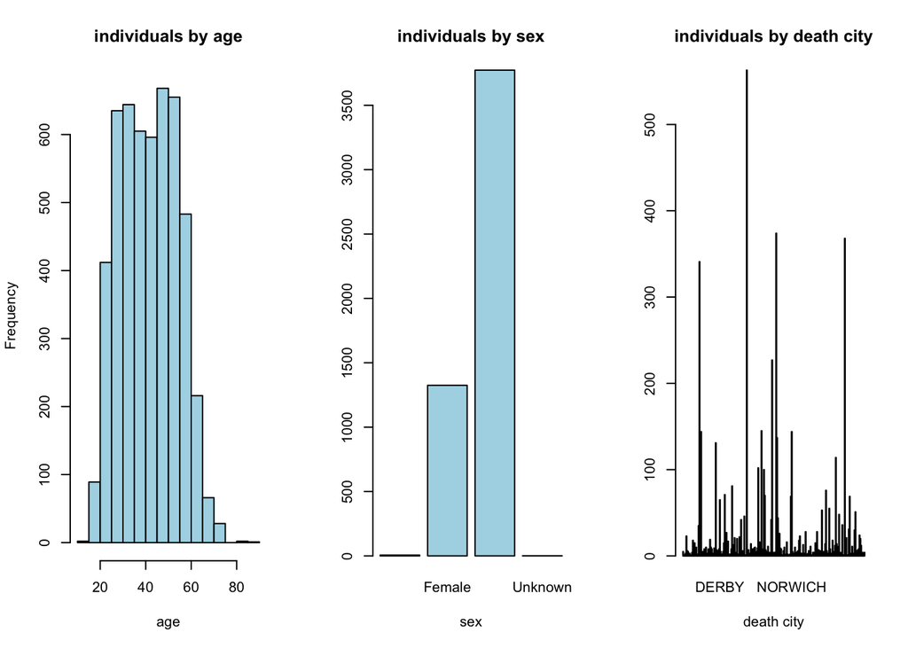

```r
# getting a visual
par(mfrow=c(1,3))
hist(na.omit(dat$Age), main="individuals by age", xlab="age", col="lightblue")
plot(dat$Sex, main="individuals by sex", xlab="sex", col="lightblue")
plot(dat$DeathCity, main="individuals by death city", xlab="death city", col="lightblue")
```

This gives us a more cohesive picture of the demographic background of a typical individual in our dataset: a white man in his early 40s.

We can also observe that there are 5 cities around which the overdose deaths reported coalesce.

# Data Cleaning and Preprocessing

Looking at the size of unique values in the cause of death attribute, we can see that this is much too broad to use.

```r
length(unique(dat$COD))
```

```
## [1] 3193
```

To hone in on opioid involvement in a given overdose, let’s instead focus on the substance attributes, which indicate whether a certain drug was detected in an individual by the Medical Examiner. We will consider an opioid to be any drug listed as an opiate or narcotic on the [Addictions and Recovery site](https://www.addictionsandrecovery.org/opioid-opiate-recovery.htm).

```r
# adding an opioid involvement attribute to our dataframe, which will be set to a value of "Yes" if a value of "Y" is found in any of the following substance attributes
dat$opioidInvolved = factor(ifelse(
  (dat$Heroin == "Y" | dat$Fentanyl == "Y" | dat$FentanylAnalogue == "Y" | dat$Oxycodone == "Y" | dat$Oxymorphone == "Y" | dat$Hydrocodone == "Y"| dat$Methadone == "Y" | dat$Tramad == "Y" | dat$Morphine_NotHeroin == "Y" | dat$Hydromorphone == "Y"),
  "Yes", "No"))
```

A breakdown of how many enteries in our data involded some kind of opioid:

```r
summary(dat$opioidInvolved)
```

```
##   No  Yes
##  616 4489
```

As we can see, opioids played a role in nearly 90% of the overdose deaths reported in our dataset. Because this percentage is so high, it doesn’t seem like it would be valuable to use this as our target variable.

Since white is the most frequently occurring race in our set of opioid overdose deaths, let’s add a binary value for this attribute as well.

```r
# adding an opioid isWhite attribute to our dataframe, which will be set to a value of "Yes" if a value of "White" is found in the race attribute
dat$isWhite = factor(ifelse(
  (dat$Race == "White"),"Yes", "No"))
```

We saw earlier in our data exploration that there were 7 enteries missing a binary sex value, the majority of which had a blank value for the attribute. Looking at the other attribute values in those rows, we can see much of the other information is blank as well.

```r
# applying a sum of the other blank columns to the rows that had a undetermined sex attribute
apply(dat[dat$Sex != 'Male' & dat$Sex != 'Female',],2,function(x) sum(x == ''))
```

```
##                  ID                Date            DateType
##                   0                   1                   1
##                 Age                 Sex                Race
##                  NA                   6                   3
##       ResidenceCity     ResidenceCounty      ResidenceState
##                   3                   3                   3
##           DeathCity         DeathCounty            Location
##                   3                   3                   3
##     LocationifOther DescriptionofInjury         InjuryPlace
##                   7                   2                   1
##          InjuryCity        InjuryCounty         InjuryState
##                   2                   2                   5
##                 COD     OtherSignifican              Heroin
##                   0                   5                   6
##             Cocaine            Fentanyl    FentanylAnalogue
##                   5                   2                   6
##           Oxycodone         Oxymorphone             Ethanol
##                   6                   7                   5
##         Hydrocodone      Benzodiazepine           Methadone
##                   6                   5                   6
##              Amphet              Tramad  Morphine_NotHeroin
##                   7                   6                   7
##       Hydromorphone               Other           OpiateNOS
##                   6                   7                   7
##           AnyOpioid       MannerofDeath        DeathCityGeo
##                   3                   1                   0
##    ResidenceCityGeo       InjuryCityGeo      opioidInvolved
##                   0                   0                   0
##             isWhite
##                   0
```

# Data Exploration and Visualization

Diving deeper into our dataset, we wanted to continue driving at demographics predicting the nature of overdose deaths.

```r
# a dataframe containing only the rows with opioid involvement
datOp = dat[dat$opioidInvolved == "Yes",]

# for later comparison, a datafram containing only the rows of overdoses with no opioid involvement
datNOp = dat[dat$opioidInvolved == "No",]
```

What is the most frequently occurring manner of death of opioid related overdoses? Does is differ from non opioid rlated deaths?

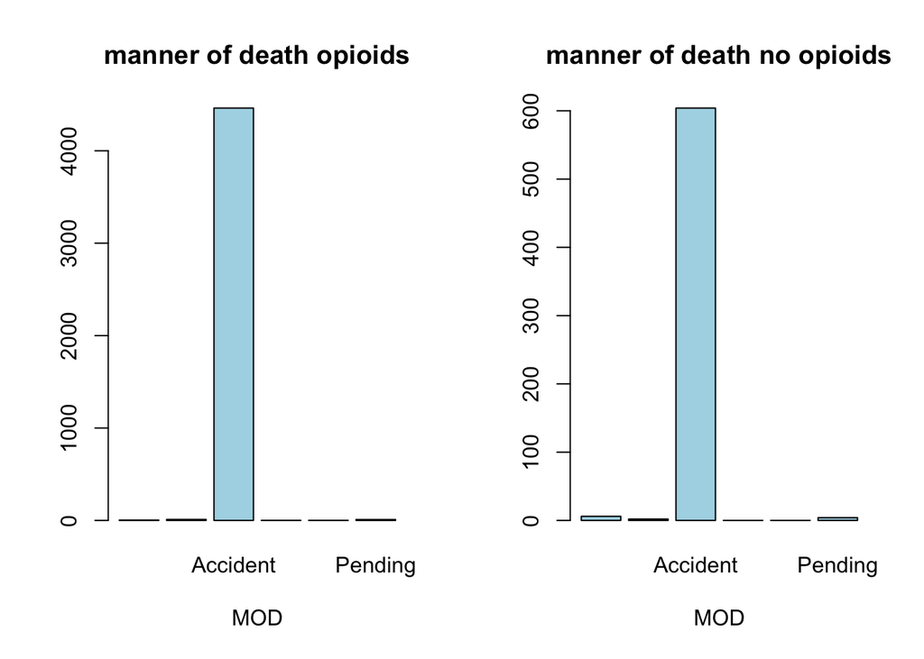

```r
# getting a count of opioid overdose deaths by month of year
par(mfrow=c(1,2))
plot(datOp$MannerofDeath, main="manner of death opioids", xlab="MOD", col="lightblue")
plot(datNOp$MannerofDeath, main="manner of death no opioids", xlab="MOD", col="lightblue")
```

We can see no difference between these subsets of our data- nearly all enteries in our dataset are accidental overdoses.

Are there any spikes in opioid overdoses depending on the time of year?

```r
# getting a count of opioid overdose deaths by month of year
datOp["Month"] = apply(datOp["Date"], 1, function(x) substr(x, 1, 2))
table(datOp$Month)
```

```
##
##  01  02  03  04  05  06  07  08  09  10  11  12
## 336 354 373 346 370 387 394 337 369 405 415 403
```

We can see the number of opioid related deaths in each month is distributed rather evenly, with a slight increase in the later months of a given year.

```r
topCities = c("HARTFORD", "NEW HAVEN","WATERBURY", "BRIDGEPORT", "NEW BRITAIN")
dat$MajorCity = factor(ifelse(dat$DeathCity %in% topCities,
 "Yes", "No"))
summary(dat$MajorCity)
```

```
##   No  Yes
## 3232 1873
```

### Building a classification tree

Our target variable is the MajorCity attribute we created in the previous section, which specifies whether or not an overdose death occurred in one of the cities with the highest death tolls. Our approach of using a classification tree is to show us what other attributes might influence this outcome. We will start constructing our classification tree by creating training and test data sets. The objective is to find predictors that minimize the our classification errors, and the functions we’ll use to do this will help us in determining what those predictors are.

```r
library(rpart)
library(rpart.plot)
library(maptree)
# for split_data function
source("https://raw.githubusercontent.com/grbruns/cst383/master/lin-regr-util.R")

set.seed(123)

splits = split_data(dat, frac=c(3,1))
tr_dat = splits[[1]]
te_dat = splits[[2]]
```

Here we are using Age, MannerofDeath, Sex, and isWHite as our predictors. We determined these to be the most useful classifiers in our dataset because all other factor attributes have far too many levels. The idea of using the classification tree is that it will aid us in discerning which attributes are most relevent to predicting the location of an overdose death.

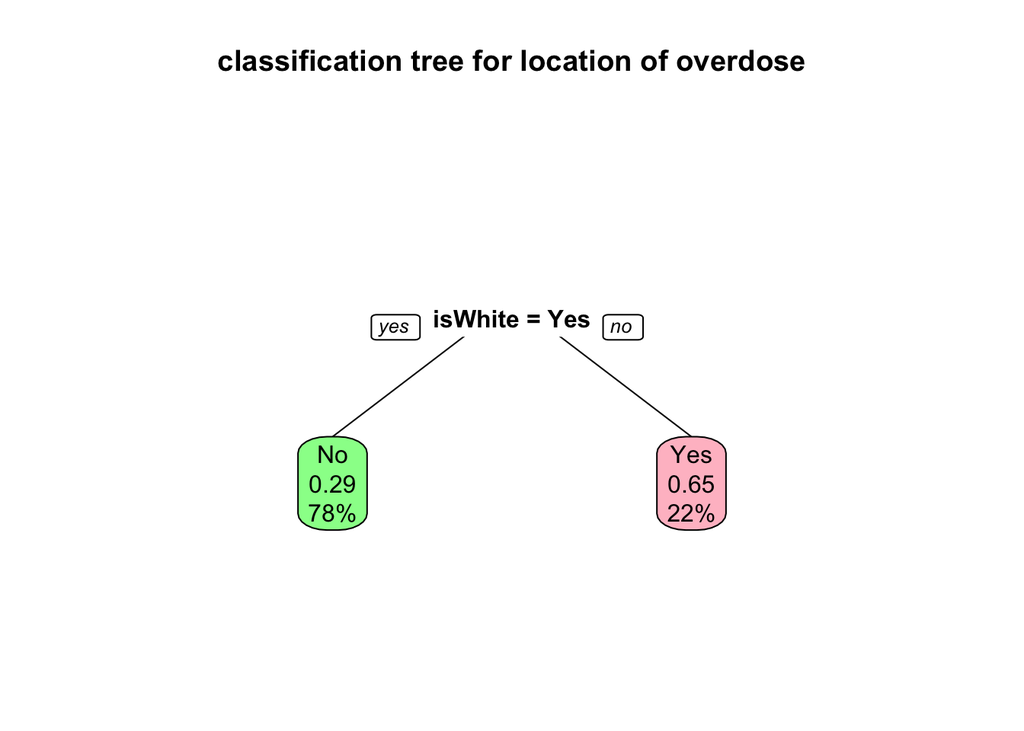

```r
# building our tree with the training data
tr_fit = rpart(MajorCity ~  Age  + MannerofDeath + isWhite + Sex , data=tr_dat, method="class")
prp(tr_fit, extra=106, varlen=-10,
 main="classification tree for location of overdose",
 box.col=c("palegreen", "pink")[tr_fit$frame$yval])
```

```r
# examining our fitted tree
summary(tr_fit)
```

```
## Call:
## rpart(formula = MajorCity ~ Age + MannerofDeath + isWhite + Sex,
##     data = tr_dat, method = "class")
##   n= 3828
##
##          CP nsplit rel error    xerror       xstd
## 1 0.1777778      0 1.0000000 1.0000000 0.02134509
## 2 0.0100000      1 0.8222222 0.8222222 0.02031748
##
## Variable importance
## isWhite
##     100
##
## Node number 1: 3828 observations,    complexity param=0.1777778
##   predicted class=No   expected loss=0.3644201  P(node) =1
##     class counts:  2433  1395
##    probabilities: 0.636 0.364
##   left son=2 (3000 obs) right son=3 (828 obs)
##   Primary splits:
##       isWhite       splits as  RL,       improve=172.0408000, (0 missing)
##       Age           < 30.5 to the left,  improve=  9.5951030, (3 missing)
##       MannerofDeath splits as  RRLL-R,   improve=  1.9867830, (0 missing)
##       Sex           splits as  LLRL,     improve=  0.2077175, (0 missing)
##   Surrogate splits:
##       Sex splits as  RLLL, agree=0.784, adj=0.001, (0 split)
##
## Node number 2: 3000 observations
##   predicted class=No   expected loss=0.2856667  P(node) =0.7836991
##     class counts:  2143   857
##    probabilities: 0.714 0.286
##
## Node number 3: 828 observations
##   predicted class=Yes  expected loss=0.3502415  P(node) =0.2163009
##     class counts:   290   538
##    probabilities: 0.350 0.650
```

### Classifying test data

We now run our classification tree on our test data

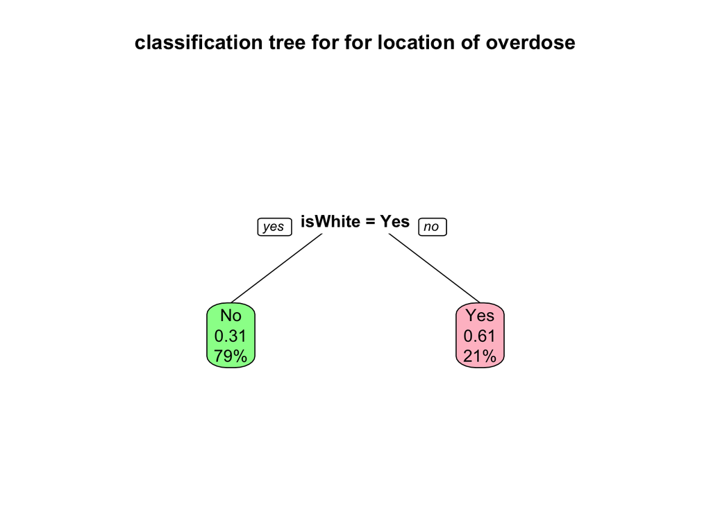

```r
# building our tree
te_fit = rpart(MajorCity ~  Age  + MannerofDeath + isWhite + Sex , data=te_dat, method="class")
prp(te_fit, extra=106, varlen=-10,
 main="classification tree for for location of overdose",
 box.col=c("palegreen", "pink")[te_fit$frame$yval])
```

### Assessing the model

```r
#creating our confusion matrix
predicted = predict(tr_fit, te_dat, type="class")
actual = te_dat$MajorCity
conf_mtx = table(predicted, actual)
conf_mtx
```

```
##          actual
## predicted  No Yes
##       No  693 311
##       Yes 106 167
```

```r
mean(actual == predicted)
```

```
## [1] 0.6734534
```

# Conclusions

We learned that white men in their 40’s are the most likely overdosees. Additionaly, we saw that dense city populations correlated to higher concentrations opioid related overdose deaths. Contrary to these initial findings, however, we found that the most likely race to overdose is *not* more likely to overdose in the most likely locations of overdose.